# Cx4073 : Assignment 2

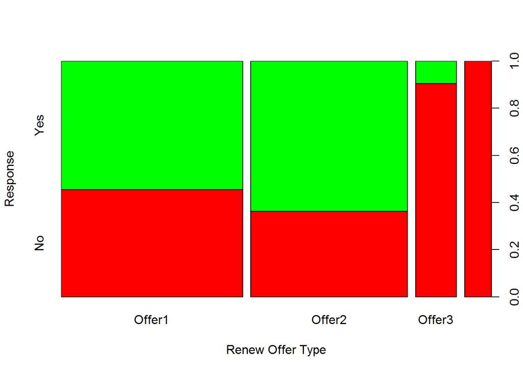

```r
plot(balOvrMarketData$Renew.Offer.Type, balOvrMarketData$Response,
     xlab="Renew Offer Type", ylab="Response", col=cols)
```

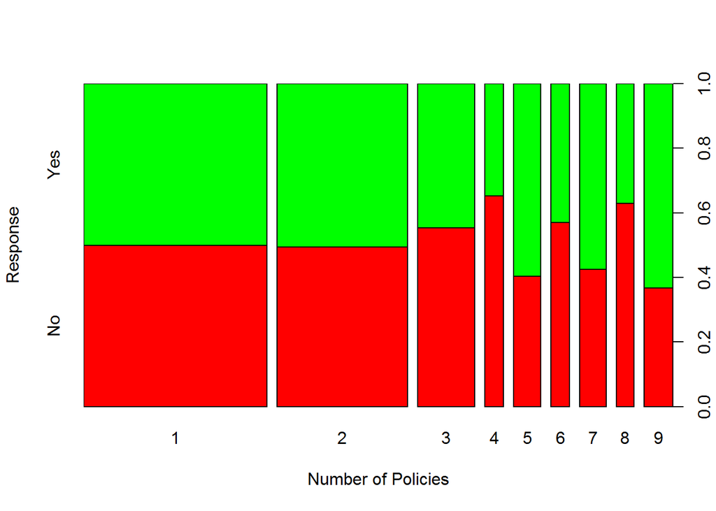

```r
plot(balOvrMarketData$Number.of.Policies, balOvrMarketData$Response,
     xlab="Number of Policies", ylab="Response", col=cols)
```

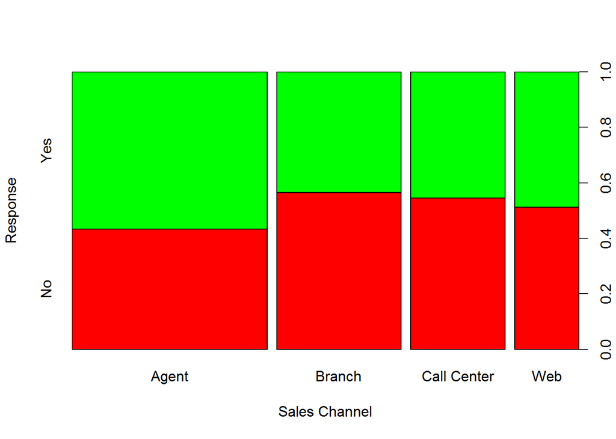

```r
plot(balOvrMarketData$Sales.Channel, balOvrMarketData$Response,
     xlab="Sales Channel", ylab="Response", col=cols)
```

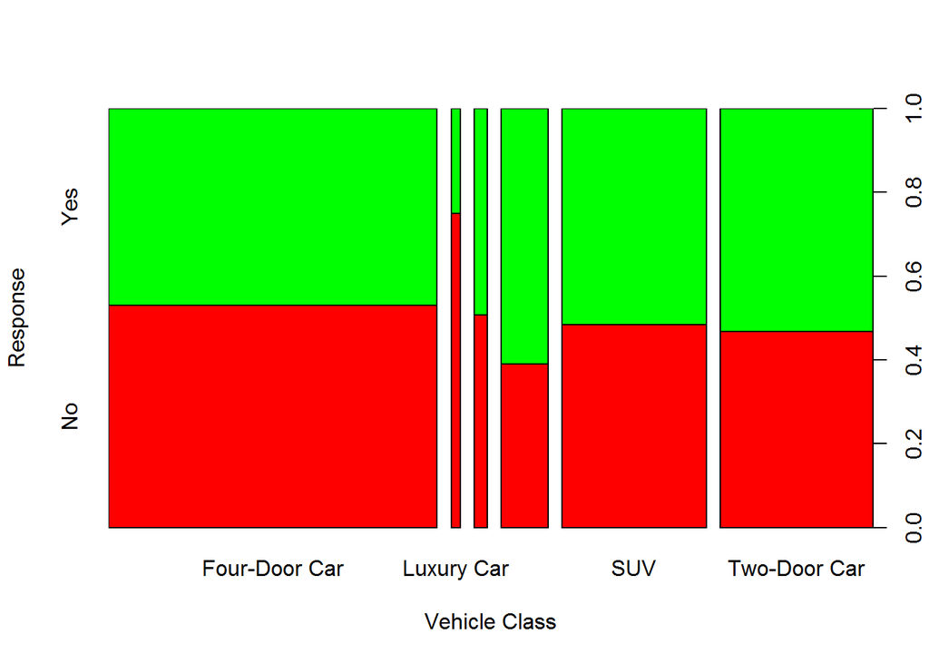

```r
plot(balOvrMarketData$Vehicle.Class, balOvrMarketData$Response,
     xlab="Vehicle Class", ylab="Response", col=cols)
```

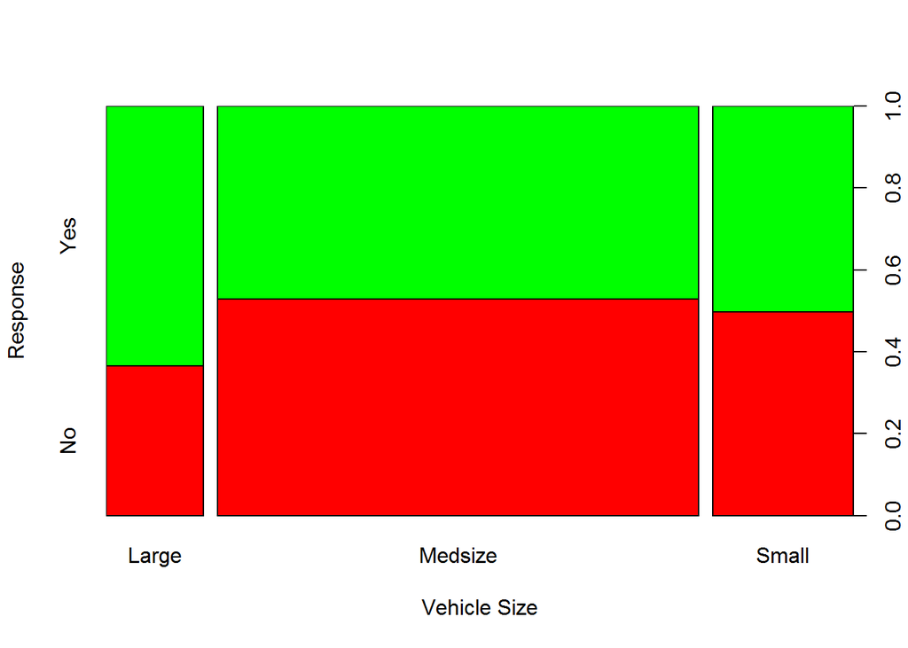

```r
plot(balOvrMarketData$Vehicle.Size, balOvrMarketData$Response,
     xlab="Vehicle Size", ylab="Response", col=cols)
```

Understanding the relationship between continuous variables and the `Response` will be same as Answer 1 as the continuous variables are all Insurance Policy.

*Model Building*

The first step is to split the data into training and testing.

```r
train <- sample(nrow(balOvrMarketData), 0.7*nrow(balOvrMarketData), replace = FALSE)
balOvrMarketDataTrain <- balOvrMarketData[train,]
balOvrMarketDataTest <- balOvrMarketData[-train,]
```

We have followed the same method as in the previous part to obtain results discussed towards the end.

```r
treeFitModel <- rpart(Response ~ ., data = balOvrMarketDataTrain, method = 'class', control = rpart.control(cp=0))
PredBase <- predict(treeFitModel, balOvrMarketDataTest, type = 'class')
accuracyBase <- mean(PredBase == balOvrMarketDataTest$Response)
accuracyBase
```

```
## [1] 0.8437635
```

```r
printcp(treeFitModel)
```

```
##
## Classification tree:
## rpart(formula = Response ~ ., data = balOvrMarketDataTrain, method = "class",
##     control = rpart.control(cp = 0))
##
## Variables actually used in tree construction:
##  [1] Coverage                      Customer.Lifetime.Value
##  [3] Education                     EmploymentStatus
##  [5] Gender                        Income
##  [7] Location.Code                 Marital.Status
##  [9] Monthly.Premium.Auto          Months.Since.Last.Claim
## [11] Months.Since.Policy.Inception Number.of.Policies
## [13] Policy                        Policy.Type
## [15] Renew.Offer.Type              Sales.Channel
## [17] State                         Total.Claim.Amount
```

[output cut: 40 more lines]

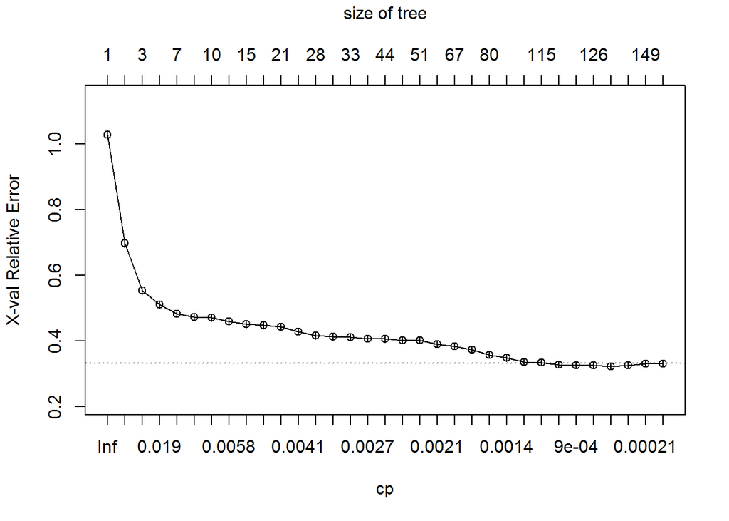

```r
plotcp(treeFitModel)
```

*Pre-Pruning*

```r
treeFitPrePrunedModel <- rpart(Response ~ ., data = balOvrMarketDataTrain, method = 'class', control = rpart.control(cp=0, maxdepth = 12,minsplit = 100))
PredBasePrePruned <- predict(treeFitPrePrunedModel, balOvrMarketDataTest, type = 'class')
accuracyPrePruned <- mean(PredBasePrePruned == balOvrMarketDataTest$Response)
accuracyPrePruned
```

```
## [1] 0.7829089
```

*Post-Pruning*

```r
treeFitPostPrunedModel <- prune(treeFitModel, cp = 0.00092)
PredBasePostPruned <- predict(treeFitPostPrunedModel, balOvrMarketDataTest, type = 'class')
accuracyPostPruned <- mean(PredBasePostPruned == balOvrMarketDataTest$Response)
accuracyPostPruned
```

```
## [1] 0.8502374
```

Confusion matrix for accuracy comparisons.

```r
predictTest <- predict(treeFitModel, balOvrMarketDataTest, type = 'class')
table_conf <- table(balOvrMarketDataTest$Response, predictTest)
table_conf
```

```
##      predictTest
##        No Yes
##   No  980 191
##   Yes 171 975
```

```r
accuracyTest <- sum(diag(table_conf))/sum(table_conf)
accuracyTest
```

```
## [1] 0.8437635
```

```r
predictTestPrePrune <- predict(treeFitPrePrunedModel, balOvrMarketDataTest, type = 'class')
table_conf_pre <- table(balOvrMarketDataTest$Response, predictTestPrePrune)
table_conf_pre
```

```
##      predictTestPrePrune
##        No Yes
##   No  874 297
##   Yes 206 940
```

```r
accuracyTestPre <- sum(diag(table_conf_pre))/sum(table_conf_pre)
accuracyTestPre
```

```
## [1] 0.7829089
```

```r
predictTestPostPrune <- predict(treeFitPostPrunedModel, balOvrMarketDataTest, type = 'class')
table_conf_post <- table(balOvrMarketDataTest$Response, predictTestPostPrune)
table_conf_post
```

```
##      predictTestPostPrune
##        No Yes
##   No  976 195
##   Yes 152 994
```

```r
accuracyTestPost <- sum(diag(table_conf_post))/sum(table_conf_post)
accuracyTestPost
```

```
## [1] 0.8502374
```

*Random Forest*

```r
rfFit <- randomForest(Response ~ .,
                      data = balOvrMarketDataTrain,
                      ntree = 1000,
                      mtry = 4,
                      importance = TRUE)

rfFit
```

```
##
## Call:
##  randomForest(formula = Response ~ ., data = balOvrMarketDataTrain,      ntree = 1000, mtry = 4, importance = TRUE)
##                Type of random forest: classification
##                      Number of trees: 1000
## No. of variables tried at each split: 4
##
##         OOB estimate of  error rate: 5.57%
## Confusion matrix:
##       No  Yes class.error
## No  2457  233  0.08661710
## Yes   68 2647  0.02504604
```

```r
predRF <- predict(rfFit, balOvrMarketDataTest, type="class")
mean(predRF == balOvrMarketDataTest$Response)
```

```
## [1] 0.9443246
```

```r
importance(rfFit)
```

```
##                                      No         Yes MeanDecreaseAccuracy
## State                          30.21280   0.7221543             21.97390
## Customer.Lifetime.Value        41.17309  78.3166678             73.32519
## Coverage                       27.03006  10.8022180             31.75478
## Education                      40.37573  71.7482253             73.72807
## EmploymentStatus               73.60430  50.8152787             92.71341
## Gender                         18.14175  38.0405231             39.26469
## Income                         75.32363  81.8229678             90.24737
## Location.Code                  40.65860  39.1655120             47.88602
## Marital.Status                 54.32437  59.0555139             64.72101
## Monthly.Premium.Auto           39.98290  69.7175976             63.54546
## Months.Since.Last.Claim        43.18214  84.0127150             86.00514
## Months.Since.Policy.Inception  49.63530  83.2874140             87.06653
## Number.of.Policies             39.08219  74.9777923             68.96544
## Policy.Type                    34.36019 -23.3063093             34.32860
## Policy                         36.89688 -16.4487605             38.08336
## Renew.Offer.Type              117.98849 128.3957303            142.15942
## Sales.Channel                  43.05800  66.4826957             66.49576
## Total.Claim.Amount             53.93762  65.0342822             84.63627
## Vehicle.Class                  27.05385  37.7415788             45.36786
## Vehicle.Size                   27.47780  44.8916074             45.10666
##                               MeanDecreaseGini
## State                                 58.43860
## Customer.Lifetime.Value              197.50592
## Coverage                              45.68373
## Education                             83.90696
## EmploymentStatus                     182.44881
## Gender                                19.90231
## Income                               324.58592
## Location.Code                         66.03566
## Marital.Status                        74.75185
## Monthly.Premium.Auto                 203.65288
## Months.Since.Last.Claim              153.66546
## Months.Since.Policy.Inception        181.86944
## Number.of.Policies                   138.74215
## Policy.Type                           72.94591
## Policy                               150.96928
## Renew.Offer.Type                     359.88502
## Sales.Channel                         79.55930
## Total.Claim.Amount                   204.03136
## Vehicle.Class                         59.61195
## Vehicle.Size                          41.10845
```

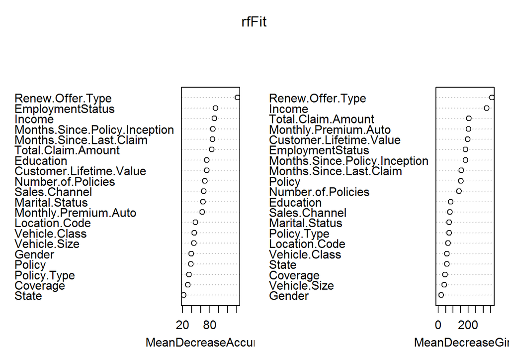

```r
varImpPlot(rfFit)
```

Boruta can be used in order to find out important features. The code is given as follows:

```r
#install.packages("Boruta")
library(Boruta)
boruta.bank_train <- Boruta(Response ~ ., data = balOvrMarketDataTrain, doTrace = 2)
```

[output not shown]

[output not shown]

[output not shown]

[output not shown]

[output not shown]

[output not shown]

[output not shown]

[output not shown]

[output not shown]

[output not shown]

[output not shown]

```
## After 11 iterations, +52 secs:
```

```
##  confirmed 19 attributes: Coverage, Customer.Lifetime.Value, Education, EmploymentStatus, Gender and 14 more;
```

```
##  still have 1 attribute left.
```

[output not shown]

[output not shown]

[output not shown]

[output not shown]

```
## After 15 iterations, +1.2 mins:
```

```
##  confirmed 1 attribute: State;
```

```
##  no more attributes left.
```

```r
print(boruta.bank_train)
```

```
## Boruta performed 15 iterations in 1.186076 mins.
##  20 attributes confirmed important: Coverage, Customer.Lifetime.Value,
## Education, EmploymentStatus, Gender and 15 more;
##  No attributes deemed unimportant.
```

We can perform prediction as follows:

```r
marketPred <- read.csv("assign2_MarketPred.csv", header = TRUE)
marketPredFiltered = subset(marketPred, select = -c(Customer, Effective.To.Date, Number.of.Open.Complaints))
marketPredFiltered$Number.of.Policies <- as.factor(marketPredFiltered$Number.of.Policies)
marketPredFiltered$Monthly.Premium.Auto <- as.numeric(marketPredFiltered$Monthly.Premium.Auto)
marketPredFiltered$Income <- as.numeric(marketPredFiltered$Income)
marketPredFiltered$Months.Since.Last.Claim <- as.numeric(marketPredFiltered$Months.Since.Last.Claim)
marketPredFiltered$Months.Since.Policy.Inception <- as.numeric(marketPredFiltered$Months.Since.Policy.Inception)

levels(marketPredFiltered$Policy) <- levels(marketData$Policy)

rfP2Pred = predict(rfFit, marketPredFiltered, type="class")

rfP2PredFrame <- data.frame("Response"=rfP2Pred)
write.csv(rfP2PredFrame, "assign2_MarketPred_Overall.csv", row.names = TRUE)
```